# Season report: LoneWolf (U1800) Season 15

#### Popular variations

All openings played in the season, including variations.

| Rank | Opening | Games | White % | 1-0 % | Draw % | 0-1 % | Mean Eval | Avg Rating |
| --- | --- | --- | --- | --- | --- | --- | --- | --- |
| 1 | Queen's Pawn Game: Mason Variation | 11 | 40.9090909090909 | 36.3636363636364 | 9.09090909090909 | 54.5454545454545 | -0.0645454545454545 | 1651.45454545455 |
| 2 | Indian Defense | 7 | 42.8571428571429 | 42.8571428571429 | 0 | 57.1428571428571 | -0.485714285714286 | 1651.28571428571 |
| 2 | Italian Game: Classical Variation, Giuoco Pianissimo | 7 | 14.2857142857143 | 14.2857142857143 | 0 | 85.7142857142857 | 1.16142857142857 | 1539.14285714286 |
| 3 | Scandinavian Defense: Mieses-Kotroc Variation | 6 | 83.3333333333333 | 83.3333333333333 | 0 | 16.6666666666667 | 1.01 | 1566.08333333333 |
| 4 | Caro-Kann Defense: Classical Variation | 5 | 60 | 60 | 0 | 40 | -0.17 | 1581.9 |
| 4 | Four Knights Game: Italian Variation | 5 | 80 | 80 | 0 | 20 | 2.06 | 1509.2 |
| 4 | Queen's Gambit Declined: Marshall Defense | 5 | 80 | 80 | 0 | 20 | 3.354 | 1504.5 |
| 4 | Queen's Pawn Game: London System | 5 | 10 | 0 | 20 | 80 | -2.4 | 1625.7 |
| 5 | Caro-Kann Defense: Advance Variation, Tal Variation | 4 | 100 | 100 | 0 | 0 | 6.8675 | 1645.5 |
| 6 | Caro-Kann Defense: Advance Variation, Botvinnik-Carls Defense | 3 | 66.6666666666667 | 66.6666666666667 | 0 | 33.3333333333333 | 1.75333333333333 | 1680.33333333333 |

[output cut: 164 more lines]

#### Best for White

The best-scoring main openings for White.

*Includes all main openings played in at least 10 games.*

| Rank | Opening | Games | White's score (%) | White wins (%) | Draws (%) | Black wins (%) | Mean eval after 15 moves | Avg rating |
| --- | --- | --- | --- | --- | --- | --- | --- | --- |
| 1 | Slav Defense | 13 | 69.2307692307692 | 69.2307692307692 | 0 | 30.7692307692308 | 1.345 | 1644.30769230769 |
| 2 | English Opening | 21 | 61.9047619047619 | 57.1428571428571 | 9.52380952380952 | 33.3333333333333 | -0.174 | 1669.57142857143 |
| 3 | Queen's Gambit Declined | 17 | 58.8235294117647 | 58.8235294117647 | 0 | 41.1764705882353 | 2.40117647058824 | 1575.38235294118 |
| 4 | Indian Defense | 14 | 57.1428571428571 | 57.1428571428571 | 0 | 42.8571428571429 | -0.1625 | 1644.14285714286 |
| 5 | Caro-Kann Defense | 26 | 53.8461538461538 | 53.8461538461538 | 0 | 46.1538461538462 | 1.662 | 1634.80769230769 |
| 6 | Italian Game | 19 | 52.6315789473684 | 52.6315789473684 | 0 | 47.3684210526316 | 1.88611111111111 | 1568.84210526316 |
| 7 | Scotch Game | 11 | 45.4545454545455 | 45.4545454545455 | 0 | 54.5454545454545 | -0.690909090909091 | 1557.5 |
| 8 | Queen's Pawn Game | 25 | 44 | 40 | 8 | 52 | -0.2148 | 1633.8 |
| 9 | French Defense | 14 | 42.8571428571429 | 28.5714285714286 | 28.5714285714286 | 42.8571428571429 | 1.41615384615385 | 1629.85714285714 |
| 10 | Sicilian Defense | 21 | 40.4761904761905 | 38.0952380952381 | 4.76190476190476 | 57.1428571428571 | 0.284 | 1569.59523809524 |

#### Best for Black

The best-scoring main openings for Black.

*Includes all main openings played in at least 10 games.*

| Rank | Opening | Games | Black's score (%) | Black wins (%) | Draws (%) | White wins (%) | Mean eval after 15 moves | Avg rating |
| --- | --- | --- | --- | --- | --- | --- | --- | --- |
| 1 | Sicilian Defense | 21 | 59.5238095238095 | 57.1428571428571 | 4.76190476190476 | 38.0952380952381 | 0.284 | 1569.59523809524 |
| 2 | French Defense | 14 | 57.1428571428571 | 42.8571428571429 | 28.5714285714286 | 28.5714285714286 | 1.41615384615385 | 1629.85714285714 |
| 3 | Queen's Pawn Game | 25 | 56 | 52 | 8 | 40 | -0.2148 | 1633.8 |
| 4 | Scotch Game | 11 | 54.5454545454545 | 54.5454545454545 | 0 | 45.4545454545455 | -0.690909090909091 | 1557.5 |
| 5 | Italian Game | 19 | 47.3684210526316 | 47.3684210526316 | 0 | 52.6315789473684 | 1.88611111111111 | 1568.84210526316 |
| 6 | Caro-Kann Defense | 26 | 46.1538461538462 | 46.1538461538462 | 0 | 53.8461538461538 | 1.662 | 1634.80769230769 |
| 7 | Indian Defense | 14 | 42.8571428571429 | 42.8571428571429 | 0 | 57.1428571428571 | -0.1625 | 1644.14285714286 |
| 8 | Queen's Gambit Declined | 17 | 41.1764705882353 | 41.1764705882353 | 0 | 58.8235294117647 | 2.40117647058824 | 1575.38235294118 |
| 9 | English Opening | 21 | 38.0952380952381 | 33.3333333333333 | 9.52380952380952 | 57.1428571428571 | -0.174 | 1669.57142857143 |
| 10 | Slav Defense | 13 | 30.7692307692308 | 30.7692307692308 | 0 | 69.2307692307692 | 1.345 | 1644.30769230769 |

#### Popular gambits

All gambit openings played in the season.[^4]

| Rank | Name | Games | White score (%) |
| --- | --- | --- | --- |
| 1 | Scotch Gambit | 4 | 25 |
| 2 | Greco Gambit | 3 | 66.6666666666667 |
| 3 | Smith-Morra Gambit | 2 | 100 |
| 4 | Geller Gambit | 1 | 100 |
| 4 | Queen's Gambit | 1 | 100 |
| 5 | Evans Gambit | 1 | 0 |
| 5 | Keidansky Gambit | 1 | 0 |

#### Gambiteers

The players who enjoyed the most success when playing gambits.[^5]

*Shows all players who scored at least 50% playing gambits in the season (min. games: 2).*

| Rank | Player | Games | % Score |
| --- | --- | --- | --- |
| 1 | LGV2018 | 4 | 50 |

### Openings - sunburst

Click on the image below to see a sunburst plot of all openings played in the season.

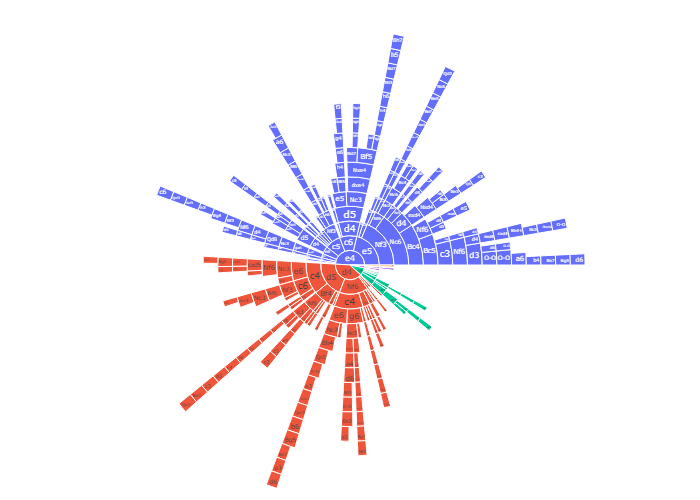

### Awards

Because winning isn’t everything; it’s the only thing :)

See the footnote for further details on selected awards.[^6]

| Award | Description | Winner | Details | Honourable mentions |
| --- | --- | --- | --- | --- |
| x | Archbishop of Accuracy | ohFLIPhere | 31.6 ACPL over 112 moves | kostasvl, marcelluspye |
| x | Bullet Boss | SouzaMoraes | 22 moves | furrykef, mmgoo |
| x | David Award | SouzaMoraes | Opponents' record: 56/79 | UncleVinny, swandog |
| x | Gambit Guru | LGV2018 | 50% from 4 games | NA |
| x | Giri Award | girmad, jkleebone, marcelluspye, Rolihlahla, TerminallyChill | 2 draws |  |
| x | Grischuk's Cousin | seius | Had 9m 52s left after 10 moves | marcelluspye, izzie26 |
| x | Houdini Award | SouzaMoraes |  | burntleaves, Numberman768 |
| x | Intimate with Increment | seius | 23.7% | izzie26, SupraScud |
| x | Musing or Snoozing | kostasvl | Spent 25m 2s | seius, PsyMar2 |
| x | MVP Award | mad_shaving | +4-4=0 perf 1716, initially 1263 | SouzaMoraes, noeom |

[output cut: 7 more lines]

### Detailed statistics

All the following tables are sortable and searchable.

#### Best performances / highest accuracy

##### Best relative perfs

Shows players’ *relative* performance ratings: season performance rating minus initial rating.[^7]

*Includes all players with a positive relative performance rating over at least five games.*

| # | Player | Games | W | D | L | Initial | Perf | Diff. |
| --- | --- | --- | --- | --- | --- | --- | --- | --- |
| 1 | mad_shaving | 8 | 4 | 0 | 4 | 1263 | 1716.5 | 453.5 |
| 2 | SouzaMoraes | 10 | 8 | 0 | 2 | 1598 | 1973.1 | 375.1 |
| 3 | noeom | 8 | 5 | 0 | 3 | 1470 | 1820.125 | 350.125 |
| 4 | ubique29 | 9 | 5 | 1 | 3 | 1526 | 1805.55555555556 | 279.555555555556 |
| 5 | Janetheus | 10 | 4 | 1 | 5 | 1419 | 1693.1 | 274.1 |
| 6 | Gallifrey42 | 9 | 1 | 1 | 7 | 1112 | 1351.11111111111 | 239.111111111111 |
| 7 | JMHWSM | 8 | 4 | 0 | 4 | 1527 | 1738.625 | 211.625 |
| 8 | rsava | 8 | 3 | 1 | 4 | 1440 | 1628 | 188 |
| 9 | jcarmody | 11 | 3 | 1 | 7 | 1249 | 1435 | 186 |
| 10 | darubaru | 10 | 5 | 1 | 4 | 1525 | 1687.7 | 162.7 |

[output cut: 15 more lines]

##### Lowest ACPL

*Includes the 100 players with the lowest ACPL (min. 100 moves played).*

| Rank | Player | Moves | ACPL |
| --- | --- | --- | --- |
| 1 | ohFLIPhere | 112 | 31.5625 |
| 2 | kostasvl | 185 | 33.9621621621622 |
| 3 | marcelluspye | 304 | 36.5559210526316 |
| 4 | aplause | 157 | 39.9235668789809 |
| 5 | jmcginty15 | 312 | 40.0128205128205 |
| 6 | Drotciv | 515 | 40.8174757281553 |
| 7 | TomasThrainsson | 419 | 40.9236276849642 |
| 8 | seius | 338 | 41.2189349112426 |
| 9 | UncleVinny | 367 | 41.6811989100817 |
| 10 | swandog | 408 | 41.8137254901961 |

[output cut: 51 more lines]

#### Time spent / strongest opponents

##### Time spent

*Includes the 50 players who spent the most clock time over the season.*

| Rank | Player | Games | Total time spent |
| --- | --- | --- | --- |
| 1 | SupraScud | 10 | 8h 49m 32s |
| 2 | Drotciv | 11 | 8h 17m 14s |
| 3 | jcarmody | 11 | 7h 54m 36s |
| 4 | seius | 11 | 7h 26m 28s |
| 5 | izzie26 | 11 | 7h 19m 52s |
| 6 | Numberman768 | 11 | 6h 43m 32s |
| 7 | swandog | 10 | 6h 40m 54s |
| 8 | UncleVinny | 10 | 6h 24m 53s |
| 9 | Boomer34 | 9 | 6h 9m 8s |
| 10 | jkleebone | 10 | 6h 8m 3s |

[output cut: 40 more lines]

##### Time spent per move (after move 10)

*Includes everyone who played at least three games.*

| Rank | Player | Games | Moves | Time spent per move | Percentile |
| --- | --- | --- | --- | --- | --- |
| 1 | dystopia753 | 3 | 39 | 1m 44.6s | 65 |
| 2 | Doevert | 3 | 49 | 1m 22.5s | 64 |
| 3 | Rolihlahla | 7 | 162 | 1m 21.4s | 63 |
| 4 | rsava | 8 | 143 | 1m 20.8s | 62 |
| 5 | Smutje41 | 4 | 65 | 1m 12.9s | 61 |
| 6 | marcelluspye | 10 | 195 | 1m 11.9s | 60 |
| 7 | JMcrath | 4 | 109 | 1m 11.8s | 59 |
| 8 | seius | 11 | 228 | 1m 11.2s | 58 |
| 9 | Akshayk06 | 4 | 86 | 1m 11.1s | 57 |
| 10 | ScacchistaImbruttito | 3 | 59 | 1m 10.6s | 56 |

[output cut: 55 more lines]

##### Strength of schedule

These players faced the most in-form opponents across the season, when judged by their opponents’ collective score in all their other games.[^8]

*Includes all players who faced a collective group of opponents that played at least 15 (other) games across the season with a collective score above 50 per cent.*

| # | Player | Opp Games | Opp Pts | Opp % |
| --- | --- | --- | --- | --- |
| 1 | SouzaMoraes | 79 | 56 | 70.8860759493671 |
| 2 | UncleVinny | 67 | 47 | 70.1492537313433 |
| 3 | swandog | 86 | 58 | 67.4418604651163 |
| 4 | burntleaves | 95 | 63.5 | 66.8421052631579 |
| 5 | ubique29 | 62 | 41 | 66.1290322580645 |
| 6 | Bennat123 | 29 | 19 | 65.5172413793103 |
| 7 | noeom | 63 | 40.5 | 64.2857142857143 |
| 8 | JMHWSM | 57 | 36 | 63.1578947368421 |
| 9 | oxygen_di_oxide | 63 | 39.5 | 62.6984126984127 |
| 10 | marcelluspye | 89 | 55.5 | 62.3595505617977 |

[output cut: 27 more lines]

#### Comebacks and upsets

##### Comebacks

*Includes players with a positive average “comeback margin” that played at least three games.*[^9]

| Rank | Player | Average Comeback Margin | Total Comeback Margin |
| --- | --- | --- | --- |
| 1 | SouzaMoraes | 1.07269697134381 | 10.7269697134381 |
| 2 | burntleaves | 0.946601722367952 | 10.4126189460475 |
| 3 | Numberman768 | 0.913835117655984 | 10.0521862942158 |
| 4 | marcelluspye | 0.888278501978374 | 9.77106352176212 |
| 5 | UpGoerFive | 0.974068698115313 | 9.74068698115313 |
| 6 | oxygen_di_oxide | 1.17215700462833 | 9.37725603702663 |
| 7 | swandog | 0.921566962953147 | 9.21566962953147 |
| 8 | Drotciv | 0.811984039388942 | 8.93182443327836 |
| 9 | seius | 0.798828653254861 | 8.78711518580347 |
| 10 | jkleebone | 0.857366590394291 | 8.57366590394291 |

[output cut: 53 more lines]

##### Biggest upsets

*Includes all players who defeated an opponent rated at least 50 points higher.*

| Rank | Player | Upset Margin |
| --- | --- | --- |
| 1 | Gallifrey42 | 484 |
| 2 | mad_shaving | 449 |
| 3 | jcarmody | 433 |
| 4 | mad_shaving | 420 |
| 5 | mad_shaving | 396 |
| 6 | mad_shaving | 347 |
| 7 | noeom | 313 |
| 8 | SupraScud | 311 |
| 9 | JMHWSM | 307 |
| 10 | Janetheus | 284 |

[output cut: 61 more lines]

##### Repeated upsets

Includes players who achieved multiple wins over opponents rated at least 50 points higher.

| Rank | Player | Total Upset Margin | Upsets | Avg Upset Margin | Biggest Margin |
| --- | --- | --- | --- | --- | --- |
| 1 | mad_shaving | 1612 | 4 | 403 | 449 |
| 2 | ubique29 | 984 | 5 | 196.8 | 223 |
| 3 | Janetheus | 867 | 4 | 216.75 | 284 |
| 4 | noeom | 792 | 4 | 198 | 313 |
| 5 | JMHWSM | 688 | 3 | 229.333333333333 | 307 |
| 6 | jcarmody | 600 | 2 | 300 | 433 |
| 7 | Drotciv | 542 | 3 | 180.666666666667 | 203 |
| 8 | kampsun | 503 | 2 | 251.5 | 255 |
| 9 | rsava | 498 | 2 | 249 | 272 |
| 10 | SouzaMoraes | 456 | 3 | 152 | 158 |

[output cut: 10 more lines]

#### Dawdlers and instant movers

##### Least time left after move 10

The players with the least time left after 10 moves…who still managed to win![^10]

| Rank | Player | Time left after 10 moves | Link |
| --- | --- | --- | --- |
| 1 | seius | 9m 52s | https://lichess.org/JBxPxfhf#20 |
| 2 | marcelluspye | 13m 12s | https://lichess.org/KOWRH8QU#19 |
| 3 | izzie26 | 14m 14s | https://lichess.org/2I50Gxco#19 |
| 4 | SupraScud | 15m 25s | https://lichess.org/RHdGpgsE#19 |
| 5 | LGV2018 | 16m 21s | https://lichess.org/Prg7WJcF#20 |
| 6 | marcelluspye | 17m 2s | https://lichess.org/iAkZRrBI#19 |
| 7 | seius | 18m 7s | https://lichess.org/xV9ss7jJ#19 |
| 8 | izzie26 | 18m 13s | https://lichess.org/5mJX54Am#20 |
| 9 | SouzaMoraes | 18m 36s | https://lichess.org/7hH3DLuT#20 |
| 10 | seius | 18m 54s | https://lichess.org/Gz32QM6D#19 |

##### Instant moves

Players who made the most ‘instant’ moves over the season, taking less than 0.5 seconds (includes premoves).

*Includes players with more than five ‘instant’ moves.*

| Rank | Player | Instant moves |
| --- | --- | --- |
| 1 | SouzaMoraes | 22 |
| 2 | furrykef | 18 |
| 3 | mmgoo | 13 |
| 4 | Rabioso | 12 |
| 5 | Min37 | 11 |
| 5 | noeom | 11 |
| 6 | Janetheus | 9 |
| 6 | jstanley | 9 |
| 6 | seius | 9 |
| 7 | aion | 8 |

[output cut: 7 more lines]

#### Longest thinks, time trouble addicts, and lucky escapes

##### Longest thinks

The longest times spent on a single move.

*Top 100 shown.*

| # | Player | Time spent | Colour | Move | Link |
| --- | --- | --- | --- | --- | --- |
| 1 | kostasvl | 25m 2s | Black | 35 | https://lichess.org/Vp3pDFxP#70 |
| 2 | seius | 15m 1s | White | 11 | https://lichess.org/boy9lObq#21 |
| 3 | PsyMar2 | 12m 56s | White | 11 | https://lichess.org/TXNe6Za9#21 |
| 4 | Rabioso | 12m 20s | Black | 41 | https://lichess.org/DGaMs4TW#82 |
| 4 | ScacchistaImbruttito | 12m 20s | Black | 50 | https://lichess.org/C1uhKoeI#100 |
| 5 | Drotciv | 11m 49s | White | 22 | https://lichess.org/UlBERex4#43 |
| 6 | Doevert | 10m 48s | Black | 13 | https://lichess.org/13uVZ8DB#26 |
| 7 | seius | 10m 41s | Black | 10 | https://lichess.org/0JfGOiYi#20 |
| 8 | marcelluspye | 10m 18s | White | 8 | https://lichess.org/iAkZRrBI#15 |
| 9 | furrykef | 10m 11s | Black | 10 | https://lichess.org/J3G2cu0g#20 |

[output cut: 90 more lines]

##### Time trouble addicts

Shows players by proportion of moves made in time trouble (defined as having less than a minute remaining on the clock).

*Includes everyone who played at least 100 moves over the season while making at least one move in time trouble.*

| # | Player | All moves | With < 1min left | Time Trouble % |
| --- | --- | --- | --- | --- |
| 1 | seius | 334 | 79 | 0.236526946107784 |
| 2 | izzie26 | 405 | 91 | 0.224691358024691 |
| 3 | SupraScud | 530 | 109 | 0.205660377358491 |
| 4 | Rolihlahla | 244 | 40 | 0.163934426229508 |
| 5 | idcmmr | 287 | 30 | 0.104529616724739 |
| 6 | Smutje41 | 103 | 7 | 0.0679611650485437 |
| 7 | JMHWSM | 338 | 20 | 0.0591715976331361 |
| 8 | Drotciv | 513 | 27 | 0.0526315789473684 |
| 9 | TerminallyChill | 315 | 15 | 0.0476190476190476 |
| 10 | rsava | 222 | 9 | 0.0405405405405405 |

[output cut: 9 more lines]

##### Saved by the bell

Players who made moves with under 5 seconds left on their clock…and still won![^11]

| Player | Moves with under 5s left | Least time left | Link |
| --- | --- | --- | --- |
| seius | 1 | 0 | https://lichess.org/JBxPxfhf |
| izzie26 | 1 | 5 | https://lichess.org/qjXtBhjA |
| SupraScud | 1 | 5 | https://lichess.org/RHdGpgsE |
| izzie26 | 1 | 5 | https://lichess.org/5mJX54Am |

#### Misc. facts

##### Lesser spotted mates

A pawn gave checkmate in 3 games: https://lichess.org/cgOGeSdB, https://lichess.org/cADcUp8s, https://lichess.org/MORhqztz.

A knight gave checkmate in 2 games: https://lichess.org/In8mfdAk, https://lichess.org/61zNzlx6.

##### Promotions

46 games had at least one promotion. 1 of these saw an under-promotion.

The most promotions seen in a game was 2: https://lichess.org/TZ5uh3ej, https://lichess.org/ydipetyc, https://lichess.org/0WLaU8Ra, https://lichess.org/2hSbaL1t, https://lichess.org/egPqMkr1, https://lichess.org/MzI4povF, https://lichess.org/Augel73t, https://lichess.org/2bqCZZKD, https://lichess.org/ZtBHLmAN, https://lichess.org/IYVkfHGk

##### Rollercoaster games

38 games featured significant winning chances for both sides (as identified by Lichess’s server analysis), comprising 14.3% of all games played.

##### Checks and captures

- Most consecutive checks: 13 (https://lichess.org/ZHALEO6y)
- Most consecutive captures: 9 (https://lichess.org/Gz32QM6D)
- Latest-occurring first capture: ply 29 in https://lichess.org/S1xBYAZZ